# MTH6139 Time Series

## 3. Run a Linear Regression Model

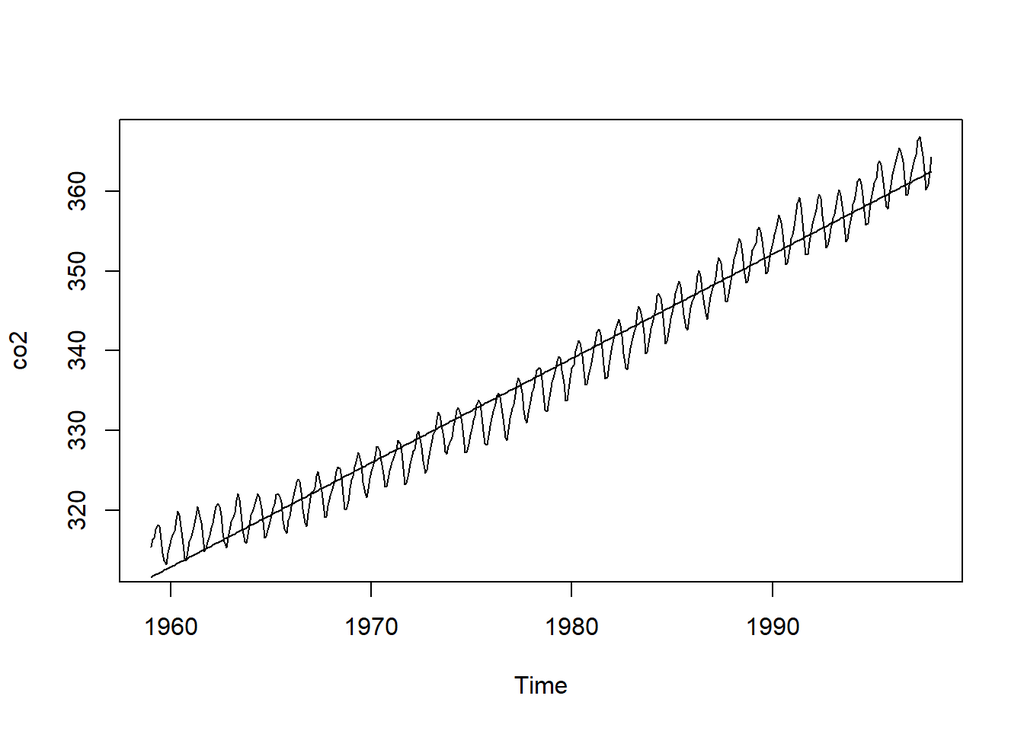

```r
reg_model=lm(co2~time(co2),na.action = NULL)
plot(co2,type="l")
lines(fitted(reg_model))
```

```r
summary(reg_model)
```

```
##
## Call:
## lm(formula = co2 ~ time(co2), na.action = NULL)
##
## Residuals:
##     Min      1Q  Median      3Q     Max
## -6.0399 -1.9476 -0.0017  1.9113  6.5149
##
## Coefficients:
##               Estimate Std. Error t value Pr(>|t|)
## (Intercept) -2.250e+03  2.127e+01  -105.8   <2e-16 ***
## time(co2)    1.308e+00  1.075e-02   121.6   <2e-16 ***
## ---
## Signif. codes:  0 '***' 0.001 '**' 0.01 '*' 0.05 '.' 0.1 ' ' 1
##
## Residual standard error: 2.618 on 466 degrees of freedom
## Multiple R-squared:  0.9695, Adjusted R-squared:  0.9694
## F-statistic: 1.479e+04 on 1 and 466 DF,  p-value: < 2.2e-16
```

## 4. Calling Prophet library

We will now use prophet to try and better model the co2 data and to do this we will use the default installation of prophet.

```r
library(prophet)
```

## 5. Setting Dataframe

Now we are going to set up our time series as an R dataframe using the co2 data so that we can use Meta’s Prophet tool on our data.

```r
co2.df = data.frame(
  ds=zoo::as.yearmon(time(co2)),
  y=co2)
```

## 6. Apply Prophet

Then we will apply Meta’s tool prophet to our co2 data and we have added in weekly and daily seasonailty so we can try and explain the seasonaility of co2 data.

```r
prophet_model = prophet::prophet(co2.df,weekly.seasonality = TRUE,daily.seasonality = TRUE)
```

## 7. Produce future data

```r
forecast = prophet::make_future_dataframe(prophet_model, periods=12, freq="quarter")
prediction = predict(prophet_model, forecast)
```

## 8. Plot Model

From this plot, the black dots are the actual reported data from the co2 data and the blue line is the predicted levels from the prophet model. It is clear from this plot that there has been a steep rise in concentration of CO<sub>2</sub> in Mauna Loa from 1960 until now, however there is clear seasonality with peaks and troughs each year however the general direction is up. We can see now that the prophet model is much better than the linear model we tried earlier as it very closely follws the real data. The part of the plot with only blue line and no black dots is the forecast prediction which shows the same trend of increasing CO<sub>2</sub> levels.The preiction from the model suggests that co2 levels will reach 370 ppm by June 2000 for the first time ever.

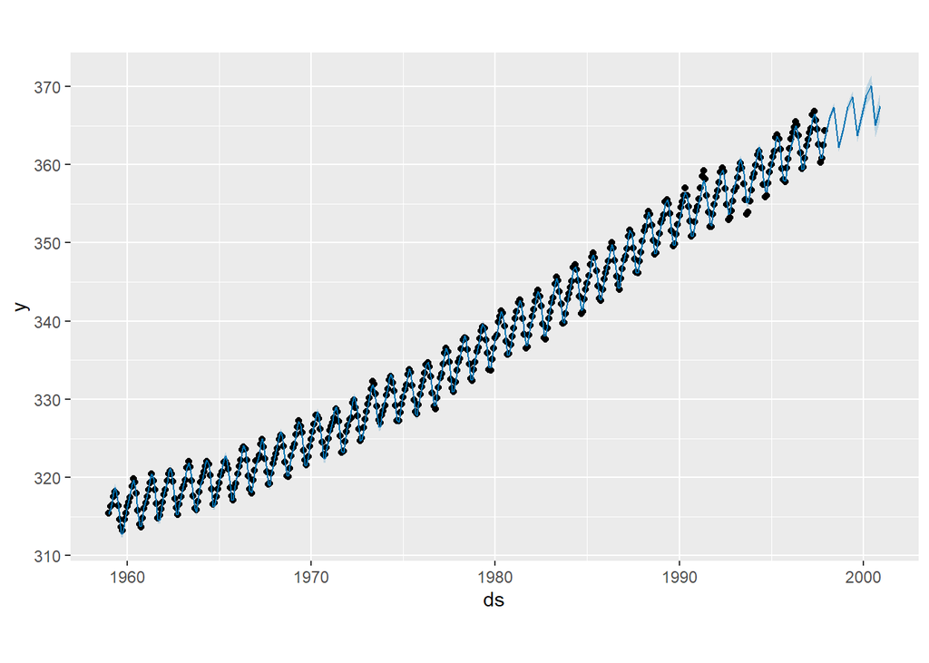

```r
plot(prophet_model,prediction)
```

## 9. Looking at Seasonality

As mentioned before, there is clear seasonality in this data and so to take a look at this we can use prophets built in function prophet_plot_components. From the output below we first of all see the trend which as I described earlier shows CO<sub>2</sub> levels steadily increase over time.

Then we see the weekly seasonality. There is a slight pattern here,that levels follow a 1/2 day cycle. Starting from Tuesday levels rise for 2 days then sink for 2 days then rise for a day then sink again for 2 days, then cycle repeats.

Then we move to yearly seasonality. It is clear to see now the cause of the peaks and troughs in the data as levels are at their highest in May and then from then on fall until October and then they start to rise again giving the seasonality.

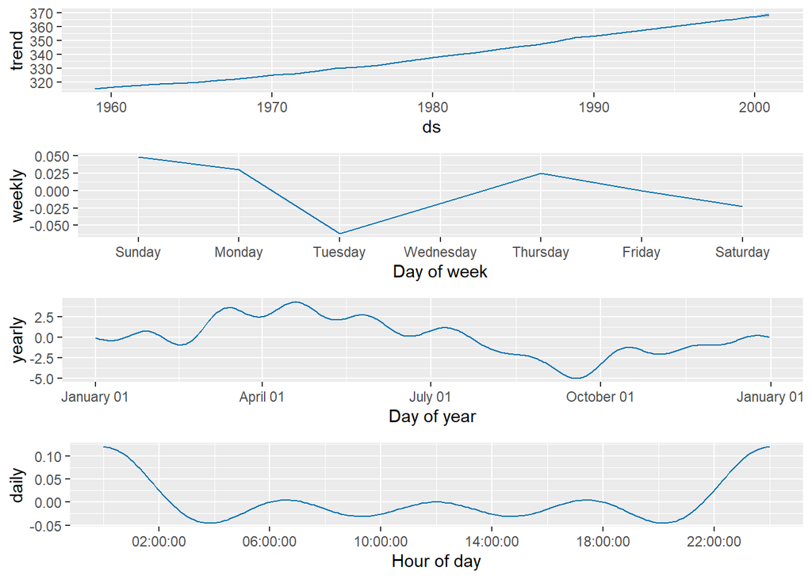

```r
prophet_plot_components(prophet_model, prediction)
```

## 10. Dyplot

We will now plot our prophet model, which is an interactive plot allowing use to go in depth into our model and see just how good our prophet model with respect to the actual data.

```r
dyplot.prophet(prophet_model, prediction)
```

[interactive chart not shown]